# Hierarchical Age-Period-Cohort model

HoxoMaxwell

2021-04-02

# 1 Introduction

https://statsnotebook.io/blog/analysis/age_period_cohort_analysis/

Epidemiologists and social scientists often apply Age-Period-Cohort (APC) analysis to disentangle trends of social/health behvaiors into three components.

- Age effect - This represents the effect associated with chronological age. For example, young people are more likely to use cannabis for recreational purpose than older people.
- Period effect - This represents the effect associated with time period that affects all age groups at the same time. For example, changes in legislation with regards to recreational cannabis use is like to influence behaviors across all age group.
- Cohort effect - Epidemiologists and social scientists are often interested in birth cohort, who experienced the same historical and social events at the same age. Cohort effect thus is often used to refered to the variation due to these unique experiences. For example, the baby boomer generation has a higher rate of cannabis use compared to subsequent cohort at the same age.

In this tutorial, we will use a simulalated data based on a nationally representative dataset in Australia and disentangle changes in cannabis use trends into age, period and cohort effect. The challenge of age-period-cohort analysis (APC analysis) has long been identified because the cohort variabls is often directly calcuated from age and period such that

Cohort = Period - Age

In this tutorial, we will use the `Hierarchical APC-Cross-Classified Random Effect Model` (`HAPC-CCREM`; Yang et al, 2008) to test the age, period and cohort effect on weekly cannabis use. This model is a type of mixed effect model in which the Age effect is entered as a fixed effect and both Cohort and Period are entered as random effects. In this setup, the HAPC-CCREM is not different from the typical application of mixed model in which the random effects often represent the contextual effects that influence the outcome. In this case, cohort represents the contextual effect of experiencing the same social and historical context at the same age within the same birth cohort and period effect represents the contextual effect of experiencing the same social and historical context at a certain time period that affects all age group.

# 2 Library

```r
library(tidyverse)
library(patchwork)
library(lme4)
library(lmerTest)
library(emmeans)
# library(equatiomatic)
```

# 3 Dataset

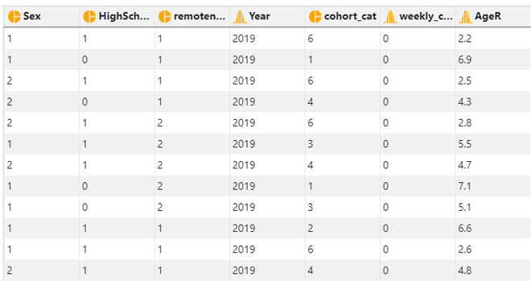

1. `Sex` - 1: Male; 2: Female
2. `HighSchool` - 0: Not completed high school; 1: completed high school
3. `remoteness` - 1: Major cities; 2: Inner regional area; 3: Remote area
4. `Year (Period)` - Year the data was collected: 2001/2004/2007/2010/2013/2016/2019
5. `cohort_cat (Cohort)` - Birth cohort: 1: 1941/50; 2: 1951/60; 3: 1961/70; 4: 1971/80; 5: 1981/90; 6: 1991/2000
6. `weekly_cannabis` - Weekly cannabis use: 0: No; 1: Yes
7. `AgeR (Age)` - Recoded age. The value is calculated by dividing the actual age by 10. This is to facilitate model converence when we add the quadratic term of age into the model.

```r
currentDataset <-read_csv(
  "https://statsnotebook.io/blog/data_management/example_data/APC_cannabis.csv"
  )
```

# 4 Explanatory Variables

```r
# Sex, HighSchool, Year, cohort_cat and remoteness as factor variable
currentDataset$Sex <- factor(currentDataset$Sex, exclude = c("", NA))
currentDataset$HighSchool <- factor(currentDataset$HighSchool,
                                    exclude = c("", NA))
currentDataset$Year <- factor(currentDataset$Year, exclude = c("", NA))
currentDataset$cohort_cat <- factor(currentDataset$cohort_cat,
                                    exclude = c("", NA))
currentDataset$remoteness <- factor(currentDataset$remoteness,
                                    exclude = c("", NA))

# Center age at 20 years old and create the quadratic term
currentDataset$AgeR <- currentDataset$AgeR - 2
currentDataset$AgeR2 <- currentDataset$AgeR ^ 2
```

# 5 APC model

At level 1, we have

$logit P({cannabis}_{ijk}) = b_{0jk} + b_{1} {\cdot} Age_{ijk} + b_{2} {\cdot} Age^{2}_{ijk} + b_{3} {\cdot} Female_{ijk} + b_{4} {\cdot} Inner regional_{ijk} + b_{5} {\cdot} Remote area_{ijk} + b_{6} {\cdot} High School_{ijk}$

At level 2, we have

$b_{0jk} = \gamma_0+ u_{0j} + v_{0k}$

where, the index $ijk$ is for individual $i$ in period $j$ and cohort $k$.

## 5.1 APC LME (HAPC-CCREM)

```r
formula.lme1 <-
    weekly_cannabis ~
    AgeR + AgeR2 + Sex + remoteness + HighSchool +
    (1 | cohort_cat) + (1 | Year)

lme1 <- glmer(formula = formula.lme1,
              family = binomial,
              data = currentDataset)
summary(lme1)
```

```
## Generalized linear mixed model fit by maximum likelihood (Laplace
##   Approximation) [glmerMod]
##  Family: binomial  ( logit )
## Formula: weekly_cannabis ~ AgeR + AgeR2 + Sex + remoteness + HighSchool +
##     (1 | cohort_cat) + (1 | Year)
##    Data: currentDataset
##
##      AIC      BIC   logLik deviance df.resid
##  33929.1  34014.3 -16955.5  33911.1    95992
##
## Scaled residuals:
##     Min      1Q  Median      3Q     Max
## -0.6598 -0.2562 -0.1820 -0.1193 20.6154
##
## Random effects:
##  Groups     Name        Variance Std.Dev.
##  Year       (Intercept) 0.01059  0.1029
##  cohort_cat (Intercept) 0.15886  0.3986
## Number of obs: 96001, groups:  Year, 7; cohort_cat, 6
##
## Fixed effects:
##             Estimate Std. Error z value Pr(>|z|)
## (Intercept) -1.47823    0.19175  -7.709 1.27e-14 ***
## AgeR        -0.49014    0.06268  -7.819 5.32e-15 ***
## AgeR2        0.01221    0.01186   1.030    0.303
## Sex2        -0.84691    0.03172 -26.697  < 2e-16 ***
## remoteness2  0.14050    0.03362   4.179 2.93e-05 ***
## remoteness3  0.30242    0.05130   5.895 3.74e-09 ***
## HighSchool1 -0.85670    0.03230 -26.521  < 2e-16 ***
## ---
## Signif. codes:  0 '***' 0.001 '**' 0.01 '*' 0.05 '.' 0.1 ' ' 1
##
## Correlation of Fixed Effects:
##             (Intr) AgeR   AgeR2  Sex2   rmtns2 rmtns3
## AgeR        -0.364
## AgeR2        0.072 -0.720
## Sex2        -0.067  0.008  0.001
## remoteness2 -0.118  0.012 -0.003  0.026
## remoteness3 -0.063 -0.014  0.005 -0.011  0.363
## HighSchool1 -0.102  0.015  0.011 -0.007  0.211  0.119
```

```r
# confint(lme1, level = 0.95, method = "Wald")

# Compute odds ratio
se <- sqrt(diag(vcov(lme1)))
z <- -qnorm((1 - 0.95) / 2)
exp(cbind(Est = fixef(lme1),
          "2.5%"  = fixef(lme1) - z * se,
          "97.5%" = fixef(lme1) + z * se))  # odds
```

```
##                   Est      2.5%     97.5%
## (Intercept) 0.2280404 0.1566014 0.3320687
## AgeR        0.6125418 0.5417249 0.6926162
## AgeR2       1.0122856 0.9890264 1.0360917
## Sex2        0.4287377 0.4028924 0.4562409
## remoteness2 1.1508512 1.0774569 1.2292450
## remoteness3 1.3531320 1.2236971 1.4962576
## HighSchool1 0.4245599 0.3985133 0.4523089
```

Age is strongly associated with reduced odds of using cannabis weekly. The quadratic term of age is not statistically significant and is very close to zero.

## 5.2 Visualize the effect of age on cannabis use

```r
Age_eff <- data.frame()

# Age is centred at 20 years old, and is divided by 10.
# (i.e. 0 means the participant is 20 years old, 1 means 30 years old, etc)
# We use a for loop to calculate the probability of weekly cannabis use
# when the age "score" is between 0 and 5, with 0.5 increment.
# The calculated probability is stored in a new data frame Age_eff

for (i in 0:10) {
  emm <- emmeans(lme1,  ~ AgeR + AgeR2,
                 at = list(AgeR = i / 2, AgeR2 = (i / 2) ^ 2),
                 type = "response",
                 level = 0.95)
  Age_eff = rbind(data.frame(summary(emm)), Age_eff)
}
Age_eff
```

```
##    AgeR AgeR2       prob          SE  df   asymp.LCL  asymp.UCL
## 1   5.0 25.00 0.01302441 0.002963280 Inf 0.008329145 0.02031226
## 2   4.5 20.25 0.01566169 0.003206712 Inf 0.010472891 0.02336060
## 3   4.0 16.00 0.01893590 0.003566890 Inf 0.013074952 0.02735125
## 4   3.5 12.25 0.02301558 0.004081239 Inf 0.016237876 0.03252876
## 5   3.0  9.00 0.02811552 0.004789430 Inf 0.020105526 0.03918906
## 6   2.5  6.25 0.03450870 0.005735311 Inf 0.024872334 0.04769591
## 7   2.0  4.00 0.04254035 0.006973858 Inf 0.030786360 0.05851100
## 8   1.5  2.25 0.05264362 0.008584237 Inf 0.038144305 0.07224044
## 9   1.0  1.00 0.06535550 0.010690410 Inf 0.047275202 0.08969955
## 10  0.5  0.25 0.08132988 0.013489649 Inf 0.058509247 0.11199258
## 11  0.0  0.00 0.10134240 0.017284082 Inf 0.072133577 0.14058661
```

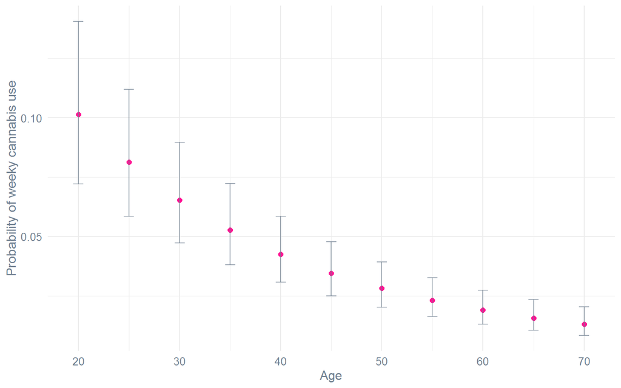

```r
p1 <- ggplot(Age_eff, aes(x = ((AgeR + 2) * 10), y = prob)) +
    geom_point(color = "deeppink", size = 2) +
    geom_errorbar(aes(ymin = asymp.LCL, ymax = asymp.UCL),
                  width = 1, color = "slategray", alpha = 0.7) +
    theme_minimal() +
    theme(axis.title = element_text(size = 12, color = "slategray"),
          axis.text = element_text(size = 10, color = "slategray")) +
    labs(x = "Age", y = "Probability of weeky cannabis use")
p1
```

# 6 LME w/o Period and Cohort

```r
formula.glm1 <-
    weekly_cannabis ~ AgeR + AgeR2 + Sex + remoteness + HighSchool

glm1 <- glm(formula = formula.glm1,
            family = binomial,
            data = currentDataset)

summary(glm1)
```

```
##
## Call:
## glm(formula = formula.glm1, family = binomial, data = currentDataset)
##
## Deviance Residuals:
##     Min       1Q   Median       3Q      Max
## -0.7629  -0.3565  -0.2568  -0.1722   3.4985
##
## Coefficients:
##              Estimate Std. Error z value Pr(>|z|)
## (Intercept) -1.405361   0.044129 -31.847  < 2e-16 ***
## AgeR        -0.191278   0.037016  -5.167 2.37e-07 ***
## AgeR2       -0.078565   0.008827  -8.901  < 2e-16 ***
## Sex2        -0.845586   0.031700 -26.675  < 2e-16 ***
## remoteness2  0.120993   0.033370   3.626 0.000288 ***
## remoteness3  0.284953   0.050961   5.592 2.25e-08 ***
## HighSchool1 -0.868696   0.032122 -27.044  < 2e-16 ***
## ---
## Signif. codes:  0 '***' 0.001 '**' 0.01 '*' 0.05 '.' 0.1 ' ' 1
##
## (Dispersion parameter for binomial family taken to be 1)
##
##     Null deviance: 37476  on 96000  degrees of freedom
## Residual deviance: 34055  on 95994  degrees of freedom
##   (86 observations deleted due to missingness)
## AIC: 34069
##
## Number of Fisher Scoring iterations: 7
```

```r
confint(glm1, level = .95, method = "Wald")
```

```
##                   2.5 %      97.5 %
## (Intercept) -1.49217748 -1.31918854
## AgeR        -0.26353847 -0.11842863
## AgeR2       -0.09599530 -0.06139235
## Sex2        -0.90788053 -0.78361194
## remoteness2  0.05561357  0.18643136
## remoteness3  0.18432639  0.38412623
## HighSchool1 -0.93176101 -0.80583937
```

## 6.1 Visualize the effect of period and cohort on cannabis use

```r
# Extract the random effect
u0 <- ranef(lme1, condVar = TRUE)
attributes(u0$Year)
```

```
## $names
## [1] "(Intercept)"
##
## $class
## [1] "data.frame"
##
## $row.names
## [1] "2001" "2004" "2007" "2010" "2013" "2016" "2019"
##
## $postVar
## , , 1
##
##             [,1]
## [1,] 0.002516939
##
## , , 2
##
##             [,1]
## [1,] 0.002527185
##
## , , 3
##
##             [,1]
## [1,] 0.002864518
##
## , , 4
##
##             [,1]
## [1,] 0.002671845
##
## , , 5
##
##             [,1]
## [1,] 0.002797855
##
## , , 6
##
##             [,1]
## [1,] 0.002715698
##
## , , 7
##
##             [,1]
## [1,] 0.002841863
```

```r
names(u0$Year) <- "est"
names(u0$cohort_cat) <- "est"

# Extract the standard error
period_eff <- data.frame(
    est = u0$Year,
    se = sqrt(attr(u0[[1]], "postVar")[1, , ]),
    period = c(2001, 2004, 2007, 2010, 2013, 2016, 2019)
    )

cohort_eff <- data.frame(
    est = u0$cohort_cat,
    se = sqrt(attr(u0[[2]], "postVar")[1, , ]),
    cohort = c("1941/50",
               "1951/60",
               "1961/70",
               "1971/80",
               "1981/90",
               "1991/2000")
  )

period_eff$upper <- period_eff$est + 1.96 * period_eff$se
period_eff$lower <- period_eff$est - 1.96 * period_eff$se
cohort_eff$upper <- cohort_eff$est + 1.96 * cohort_eff$se
cohort_eff$lower <- cohort_eff$est - 1.96 * cohort_eff$se
```

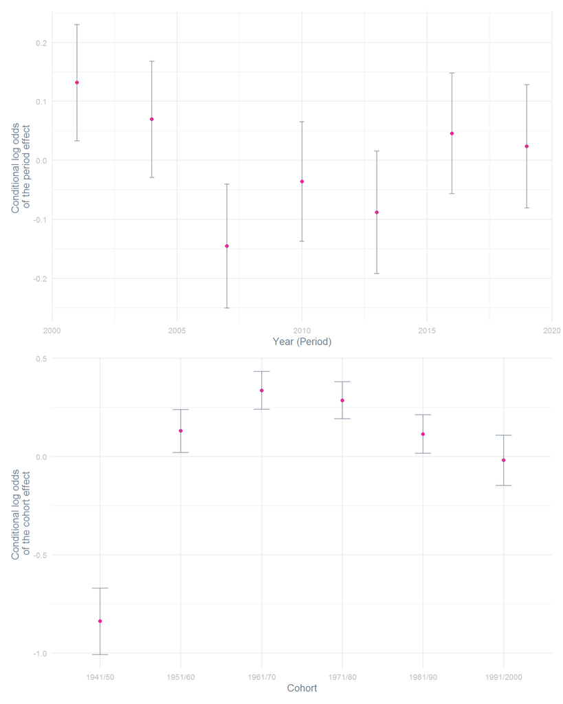

```r
p2 <- ggplot(period_eff, aes(x = period, y = est)) +
    geom_point(color = "deeppink") +
    geom_errorbar(aes(ymin = lower, ymax = upper),
                  width = .2, color = "slategray", alpha = 0.7) +
    theme_minimal() +
    theme(axis.title = element_text(size = 10, color = "slategray"),
          axis.text = element_text(size = 8, color = "gray")) +
    labs(x = "Year (Period)", y = "Conditional log odds \nof the period effect")

p3 <- ggplot(cohort_eff, aes(x = cohort, y = est)) +
    geom_point(color = "deeppink") +
    geom_errorbar(aes(ymin = lower, ymax = upper),
                  width = .2, color = "slategray", alpha = 0.7) +
    theme_minimal() +
    theme(axis.title = element_text(size = 10, color = "slategray"),
          axis.text = element_text(size = 8, color = "gray")) +
    labs(x = "Cohort", y = "Conditional log odds \nof the cohort effect")

p2 / p3
```

# 7 Model Comparison

```r
anova(lme1, glm1)
```

```
## Data: currentDataset
## Models:
## glm1: formula.glm1
## lme1: weekly_cannabis ~ AgeR + AgeR2 + Sex + remoteness + HighSchool +
## lme1:     (1 | cohort_cat) + (1 | Year)
##      npar   AIC   BIC logLik deviance Chisq Df Pr(>Chisq)
## glm1    7 34069 34136 -17028    34055
## lme1    9 33929 34014 -16956    33911 144.2  2  < 2.2e-16 ***
## ---
## Signif. codes:  0 '***' 0.001 '**' 0.01 '*' 0.05 '.' 0.1 ' ' 1
```

# 8 EOF